# AirQuality Analysis

Ashish Jha

3/1/2018

**Reading file into R**

```r
library(readxl)
df <- read_excel("AirQualityUCI.xlsx")
View(df)
```

*Getting Structure of the dataset*

```r
str(df)
```

```
## Classes 'tbl_df', 'tbl' and 'data.frame':    9357 obs. of  15 variables:
##  $ Date         : POSIXct, format: "2004-03-10" "2004-03-10" ...
##  $ Time         : POSIXct, format: "1899-12-31 18:00:00" "1899-12-31 19:00:00" ...
##  $ CO(GT)       : num  2.6 2 2.2 2.2 1.6 1.2 1.2 1 0.9 0.6 ...
##  $ PT08.S1(CO)  : num  1360 1292 1402 1376 1272 ...
##  $ NMHC(GT)     : num  150 112 88 80 51 38 31 31 24 19 ...
##  $ C6H6(GT)     : num  11.88 9.4 9 9.23 6.52 ...
##  $ PT08.S2(NMHC): num  1046 955 939 948 836 ...
##  $ NOx(GT)      : num  166 103 131 172 131 89 62 62 45 -200 ...
##  $ PT08.S3(NOx) : num  1056 1174 1140 1092 1205 ...
##  $ NO2(GT)      : num  113 92 114 122 116 96 77 76 60 -200 ...
##  $ PT08.S4(NO2) : num  1692 1559 1554 1584 1490 ...
##  $ PT08.S5(O3)  : num  1268 972 1074 1203 1110 ...
##  $ T            : num  13.6 13.3 11.9 11 11.2 ...
##  $ RH           : num  48.9 47.7 54 60 59.6 ...
##  $ AH           : num  0.758 0.725 0.75 0.787 0.789 ...
```

**Getting summary of the dataset**

```r
# Since missing values are marked as -200
df[df == -200] <- NA

summary(df)
```

```
##       Date                          Time
##  Min.   :2004-03-10 00:00:00   Min.   :1899-12-31 00:00:00
##  1st Qu.:2004-06-16 00:00:00   1st Qu.:1899-12-31 05:00:00
##  Median :2004-09-21 00:00:00   Median :1899-12-31 11:00:00
##  Mean   :2004-09-21 04:30:05   Mean   :1899-12-31 11:29:55
##  3rd Qu.:2004-12-28 00:00:00   3rd Qu.:1899-12-31 18:00:00
##  Max.   :2005-04-04 00:00:00   Max.   :1899-12-31 23:00:00
##
##      CO(GT)        PT08.S1(CO)        NMHC(GT)         C6H6(GT)
##  Min.   : 0.100   Min.   : 647.2   Min.   :   7.0   Min.   : 0.149
##  1st Qu.: 1.100   1st Qu.: 936.8   1st Qu.:  67.0   1st Qu.: 4.437
##  Median : 1.800   Median :1063.0   Median : 150.0   Median : 8.240
##  Mean   : 2.153   Mean   :1099.7   Mean   : 218.8   Mean   :10.083
##  3rd Qu.: 2.900   3rd Qu.:1231.2   3rd Qu.: 297.0   3rd Qu.:13.989
##  Max.   :11.900   Max.   :2039.8   Max.   :1189.0   Max.   :63.742
##  NA's   :1683     NA's   :366      NA's   :8443     NA's   :366
##  PT08.S2(NMHC)       NOx(GT)        PT08.S3(NOx)       NO2(GT)
##  Min.   : 383.2   Min.   :   2.0   Min.   : 322.0   Min.   :  2.0
##  1st Qu.: 734.4   1st Qu.:  98.0   1st Qu.: 657.9   1st Qu.: 78.0
##  Median : 909.0   Median : 179.8   Median : 805.5   Median :109.0
##  Mean   : 939.0   Mean   : 246.9   Mean   : 835.4   Mean   :113.1
##  3rd Qu.:1116.2   3rd Qu.: 326.0   3rd Qu.: 969.2   3rd Qu.:142.0
##  Max.   :2214.0   Max.   :1479.0   Max.   :2682.8   Max.   :339.7
##  NA's   :366      NA's   :1639     NA's   :366      NA's   :1642
##   PT08.S4(NO2)   PT08.S5(O3)           T               RH
##  Min.   : 551   Min.   : 221.0   Min.   :-1.90   Min.   : 9.175
##  1st Qu.:1227   1st Qu.: 731.4   1st Qu.:11.79   1st Qu.:35.812
##  Median :1463   Median : 963.2   Median :17.75   Median :49.550
##  Mean   :1456   Mean   :1022.8   Mean   :18.32   Mean   :49.232
##  3rd Qu.:1674   3rd Qu.:1273.4   3rd Qu.:24.40   3rd Qu.:62.500
##  Max.   :2775   Max.   :2522.8   Max.   :44.60   Max.   :88.725
##  NA's   :366    NA's   :366      NA's   :366     NA's   :366
##        AH
##  Min.   :0.1847
##  1st Qu.:0.7368
##  Median :0.9954
##  Mean   :1.0255
##  3rd Qu.:1.3137
##  Max.   :2.2310
##  NA's   :366
```

**Visualizing missing values in dataframe**

```r
library(lattice)
library(VIM)
library(mice)
df_ <- df[,-c(1,2)]
nhanes_miss = aggr(df_, col=mdc(1:2), numbers=TRUE, sortVars=TRUE, labels=names(df.mis), cex.axis=.7, gap=3, ylab=c("Proportion of missingness","Missingness Pattern"))
```

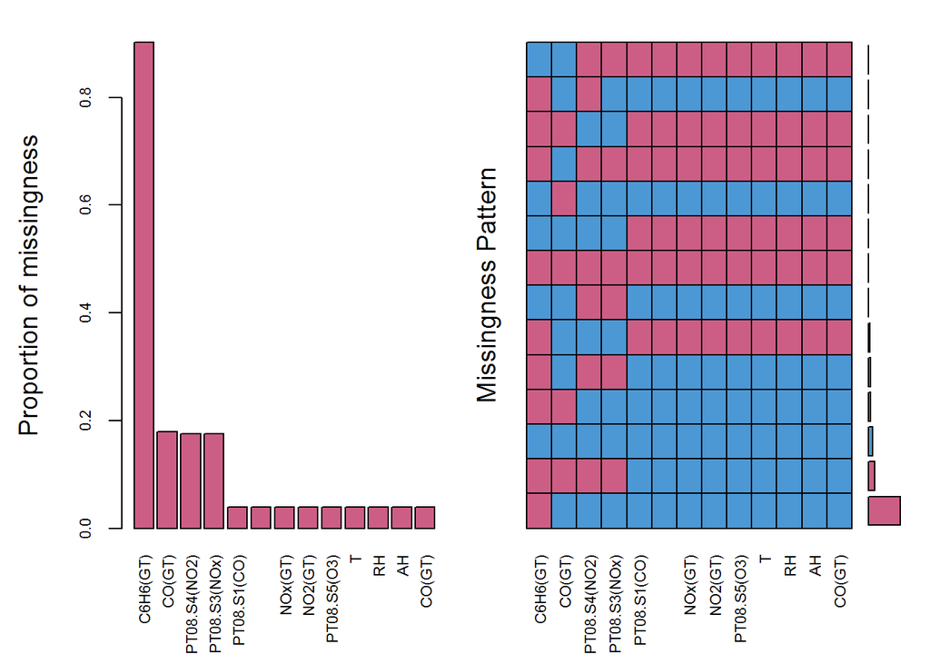

```
##
##  Variables sorted by number of missings:
##       Variable     Count
##       C6H6(GT) 0.9023191
##         CO(GT) 0.1798653
##   PT08.S4(NO2) 0.1754836
##   PT08.S3(NOx) 0.1751630
##    PT08.S1(CO) 0.0391151
##  PT08.S2(NMHC) 0.0391151
##        NOx(GT) 0.0391151
##        NO2(GT) 0.0391151
##    PT08.S5(O3) 0.0391151
##              T 0.0391151
##             RH 0.0391151
##             AH 0.0391151
##         CO(GT) 0.0391151
```

*Clearly NMHC(GT) column has too many missing values hence can’t be imputed.*

```r
df <- subset(df, select = -c(5))
df.mis <- subset(df, select = -c(1, 2))
```

**Imputing missing values using MICE**

```r
# Imputing missing values using mice
library(mice)
mice_imputes = mice(df.mis, m = 5, maxit = 10)
```

```r
mice_imputes$method
```

```
##        CO(GT)   PT08.S1(CO)      C6H6(GT) PT08.S2(NMHC)       NOx(GT)
##         "pmm"         "pmm"         "pmm"         "pmm"         "pmm"
##  PT08.S3(NOx)       NO2(GT)  PT08.S4(NO2)   PT08.S5(O3)             T
##         "pmm"         "pmm"         "pmm"         "pmm"         "pmm"
##            RH            AH
##         "pmm"         "pmm"
```

```r
Imputed_data = complete(mice_imputes, 3)
```

**Forming a dataset(dff) in which no value is missing hence can be evaluated further**

```r
df_DT <- subset(df, select = c(1, 2))
dff <- cbind(df_DT, Imputed_data)
```

**Visualizing distribution of different variables**

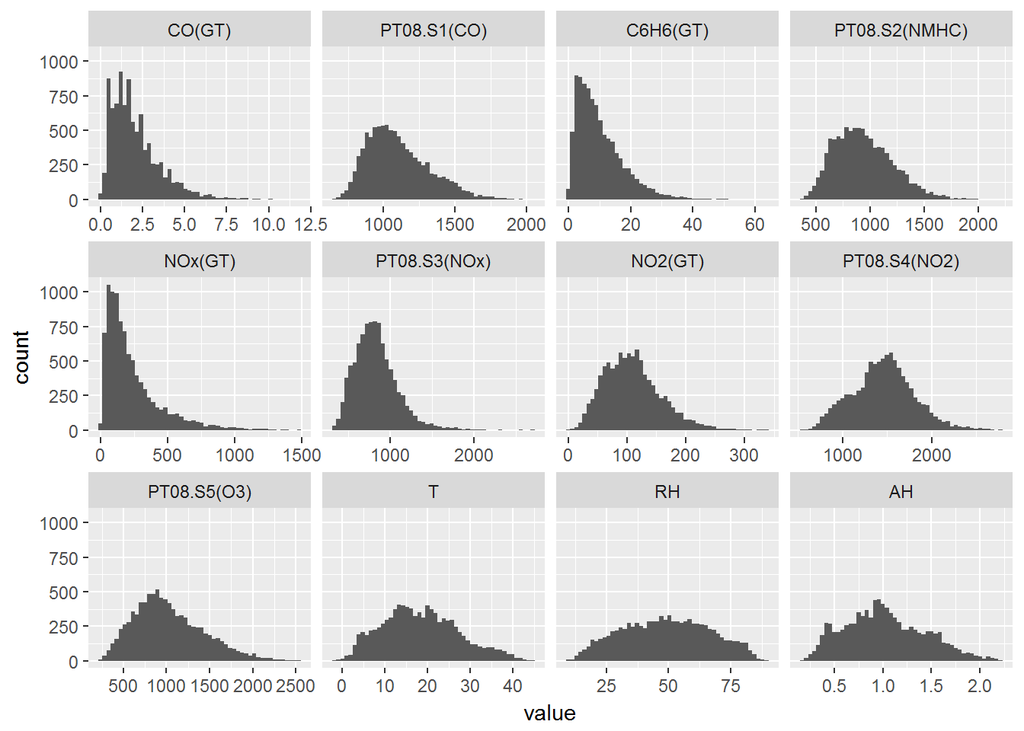

```r
library(reshape2)
library(ggplot2)

ggplot(data = melt(dff[, -c(1, 2, 15)]), mapping = aes(x = value)) + geom_histogram(bins = 50) +
    facet_wrap(~variable, scales = "free_x")
```

**Combining data and time columns**

```r
Hours <- format(as.POSIXct(strptime(dff$Time, "%Y-%m-%d %H:%M:%S", tz = "")),
    format = "%H:%M")
dff$datetime <- as.POSIXct(paste(dff$Date, Hours), format = "%Y-%m-%d %H:%M")
```

**Time Series plot to visually recognize the stationarity of series**

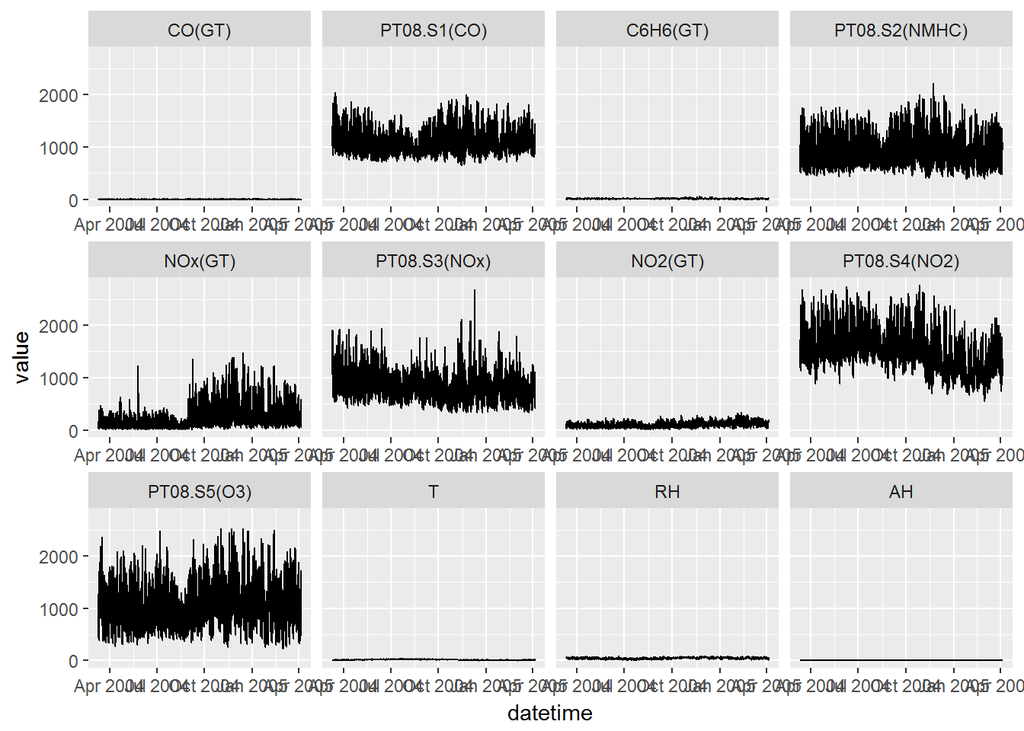

```r
library(ggplot2)
library(reshape2)
meltdf <- melt(dff[, -c(1, 2)], id = "datetime")
# ggplot(meltdf,aes(x=datetime,y=value,colour=variable,group=variable)) +
# geom_line()

ggplot(data = meltdf, mapping = aes(y = value, x = datetime)) + geom_line() +
    facet_wrap(~variable, scales = "free_x")
```

```r
# test-train split
df_test <- subset(dff, datetime >= as.POSIXct("2005-04-04 00:00"))
df_train <- subset(dff, datetime < as.POSIXct("2005-04-04 00:00"))
```

**Forecating variables as univariate time series**

```r
require(xts)
require(forecast)
time_index <- seq(from = as.POSIXct("2004-03-10 18:00"), to = as.POSIXct("2005-04-03 23:00"),
    by = "hour")
accuracy <- matrix(ncol = 7, nrow = 12)
j = 1
for (i in 3:14) {
    ts <- xts(df_train[, i], order.by = time_index)

    fit <- auto.arima(ts)
    # obtaining accuray of each fit

    accuracy[j, ] <- accuracy(fit)
    j = j + 1
}
```

```r
acc_df <- data.frame(accuracy)
colnames(acc_df) <- c("ME", "RMSE", "MAE", "MPE", "MAPE", "MASE", "ACF1")
acc_df$variable <- c("CO(GT)", "PT08.S1(CO)", "C6H6(GT)", "PT08.S2(NMHC)", "NOx(GT)",
    "PT08.S3(NOx)", "NO2(GT)", "PT08.S4(NO2)", "PT08.S5(O3)", "T", "RH", "AH")

# Printing RMSE of timeseires forecast associated with the variable
acc_df[, c("RMSE", "variable")]
```

```
##           RMSE      variable
## 1    0.7825814        CO(GT)
## 2  100.7374826   PT08.S1(CO)
## 3    3.9536425      C6H6(GT)
## 4  128.7077892 PT08.S2(NMHC)
## 5   97.0827252       NOx(GT)
## 6  110.6757317  PT08.S3(NOx)
## 7   22.6298291       NO2(GT)
## 8  149.9257788  PT08.S4(NO2)
## 9  171.2447646   PT08.S5(O3)
## 10   2.3662042             T
## 11   6.3627386            RH
## 12   0.1261314            AH
```

**Fitting an ARIMAX model**  
Previously we have not considered the effect of other variable over the forecast of one variable.  
Now lets take one varible to forecast (let say CO(GT)) and input other variables as exogenous regressors and compare the RMSE of previous univariate timeseries associated with that variable.

```r
ts <- xts(df_train[, 3], order.by = time_index)
# fitting arima model with exogenious variable
fit_x <- auto.arima(ts, xreg = df_train[, -c(1, 2, 3, 15)], trace = TRUE)
```

```
##
##  Fitting models using approximations to speed things up...
##
##  ARIMA(2,0,2) with non-zero mean : 4114.623
##  ARIMA(0,0,0) with non-zero mean : 10153.72
##  ARIMA(1,0,0) with non-zero mean : 4828.207
##  ARIMA(0,0,1) with non-zero mean : 6929.316
##  ARIMA(0,0,0) with zero mean     : 10252.01
##  ARIMA(1,0,2) with non-zero mean : 4115.583
##  ARIMA(3,0,2) with non-zero mean : 4115.999
##  ARIMA(2,0,1) with non-zero mean : 4112.657
##  ARIMA(2,0,1) with zero mean     : 4115.566
##  ARIMA(1,0,1) with non-zero mean : 4199.622
##  ARIMA(3,0,1) with non-zero mean : 4115.458
##  ARIMA(2,0,0) with non-zero mean : 4438.163
##
##  Now re-fitting the best model(s) without approximations...
##
##  ARIMA(2,0,1) with non-zero mean : 4112.007
##
##  Best model: Regression with ARIMA(2,0,1) errors
```

```r
# forecating the timeseries
pred <- forecast(fit_x, xreg = df_test[, -c(1, 2, 3, 15)], h = 15)
```

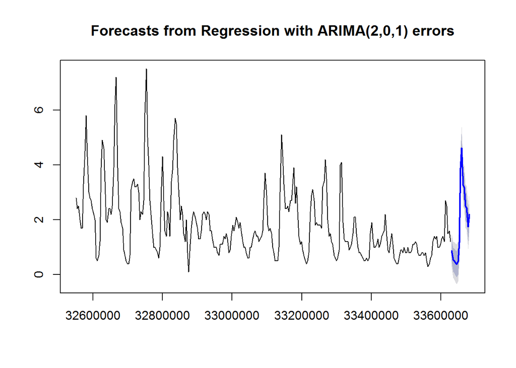

```r
plot(pred, include = 300)
```

**calculating RMSE of the fit**

```r
predDF <- as.data.frame(pred)
rmse <- sqrt(sum((predDF$`Point Forecast` - df_test[, 3])^2)/15)

rmse
```

```
## [1] 0.2205473
```

[output not shown]

Clearly there is a significant rise in quality of model fit. We can perform similar analysis with other variables too and get an improved model.